# Business and Biopdiversity - Ch 4 - Snowball Pilot

Author

Rainer M Krug Rainer.Krug@senckenberg.de Rainer@krugs.de

# Setup

```r
#|
if (!exists("params")){
    params <- rmarkdown::yaml_front_matter('~/Documents_Local/git/IPBES_data_tsu/Assessments/Business/IPBES_BBA_Ch4-Snowball_Pilot_1/snowball.qmd')$params
}

# library(bibtex)
library(openalexR)
library(writexl)
library(tibble)
library(dplyr)
library(ggplot2)
library(ggraph)
library(tidygraph)
library(knitr)

list.files(
    "R",
    full.names = TRUE,
    recursive = TRUE
) |>
    sapply(
        FUN <- source
    )
```

```
        R/plot_snowball.R R/to_xlsx.R
value   ?                 ?
visible FALSE             FALSE
```

```r
kp <- read.csv(file.path("Key Papers", params$key_paper))
```

# Back to [Readme](https://rkrug.github.io/IPBES_BBA_Ch4_Snowball_Pilot_1/)

# Searches

## OpenAlex

### Setup OpelAnex usage and do snowball serarch

```r
#|

key_works <- oa_fetch(
    entity = "works",
    doi = kp$DOI,
    verbose = FALSE
)



saveRDS(key_works, file.path("data", "key_works.rds"))

ids <- openalexR:::shorten_oaid(key_works$id)

fn <- file.path(".", "data", "snowball.rds")
if (file.exists(fn)) {
    snowball <- readRDS(fn)
} else {
    snowball <- oa_snowball(
        identifier = ids,
        verbose = FALSE
    )
    saveRDS(snowball, fn)
}

flat_snow <- snowball2df(snowball) |>
    as_tibble()
```

```r
#|

###

fn <- file.path(".", "data", "snowball.xlsx")
to_xlsx(
    snowball = snowball,
    flat_snow = flat_snow,
    xls_filename = fn
)
```

The column are: (the Concept columns are not that relevant at the moment)

- **id**: internal id fromOpenAlex
- **author**: authors of the paper
- **publication_year**: publication year
- **title**: title of the paper
- **doi**: doi of the paper
- **no_referenced_works**: number of references in the paper which are also in OpenAlex
- **cited_global**: Number of times the paper has been cited
- **cited_global_per_year**: standardised number of times cirted (cited_global / number of years published)
- **no_connections**: number of connections in the rgaph, i.e. either cited or citing a paper in the snowball corpus
- **concepts_l0**: Concept 0. level assigned by OpenAlex
- **concepts_l1**: Concept 1. level assigned by OpenAlex
- **concepts_l2**: Concept 2. level assigned by OpenAlex
- **concepts_l3**: Concept 3. level assigned by OpenAlex
- **concepts_l4**: Concept 4. level assigned by OpenAlex
- **concepts_l5**: Concept 5. level assigned by OpenAlex
- **author_institute**: Institute of the authors
- **institute_country**: Country of the institute
- **abstract**: the abstract of the paper

### Graph of links between references

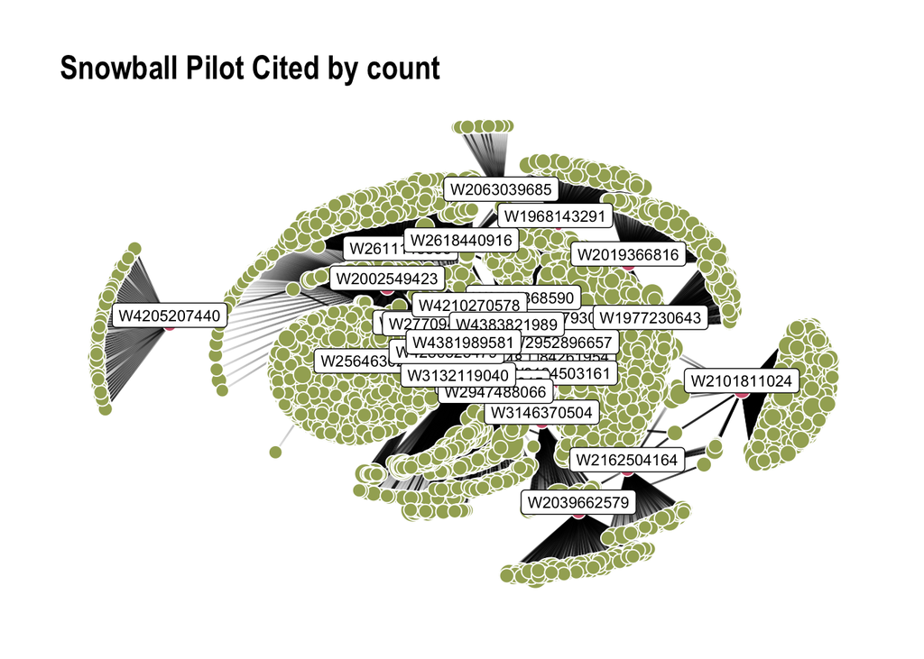

```r
#|
plot_snowball(
    snowball,
    name = "Snowball Pilot"
)
```

### Identification of references with more than one edge

This is the number of connections (`connection_count)`of the paper (`id`)

```r
#|
mult_edge <- flat_snow |>
    select(id, connection_count) |>
    filter(connection_count > 1) |>
    arrange(desc(connection_count))

links <- flat_snow |>
    filter(id %in% mult_edge$id)

links |>
    select(id, display_name, publication_year, doi, connection_count) |>
    arrange(desc(connection_count)) |>
    knitr::kable()
```

| id | display_name | publication_year | doi | connection_count |
| --- | --- | --- | --- | --- |
| W2564630286 | ReCiPe2016: a harmonised life cycle impact assessment method at midpoint and endpoint level | 2016 | https://doi.org/10.1007/s11367-016-1246-y | 1659 |
| W2101811024 | Global indicators of biological invasion: species numbers, biodiversity impact and policy responses | 2010 | https://doi.org/10.1111/j.1472-4642.2009.00633.x | 515 |
| W2035279307 | GLOBIO3: A Framework to Investigate Options for Reducing Global Terrestrial Biodiversity Loss | 2009 | https://doi.org/10.1007/s10021-009-9229-5 | 460 |
| W3084261954 | Bending the curve of terrestrial biodiversity needs an integrated strategy | 2020 | https://doi.org/10.1038/s41586-020-2705-y | 399 |
| W2611148533 | Systems Thinking for Life Cycle Sustainability Assessment: A Review of Recent Developments, Applications, and Future Perspectives | 2017 | https://doi.org/10.3390/su9050706 | 300 |
| W2912085350 | IMPACT World+: a globally regionalized life cycle impact assessment method | 2019 | https://doi.org/10.1007/s11367-019-01583-0 | 267 |
| W2019366816 | Assessing the impacts of livestock production on biodiversity in rangeland ecosystems | 2012 | https://doi.org/10.1073/pnas.1011013108 | 233 |
| W3124503161 | A review of the interactions between biodiversity, agriculture, climate change, and international trade: research and policy priorities | 2021 | https://doi.org/10.1016/j.oneear.2020.12.008 | 211 |
| W1968143291 | Biodiversity in environmental assessment—current practice and tools for prediction | 2006 | https://doi.org/10.1016/j.eiar.2005.09.001 | 171 |
| W4383821989 | Life-cycle assessment to guide solutions for the triple planetary crisis | 2023 | https://doi.org/10.1038/s43017-023-00449-2 | 171 |
| W3132119040 | Ecosystem services and life cycle assessment: A bibliometric review | 2021 | https://doi.org/10.1016/j.resconrec.2021.105461 | 166 |
| W2952896657 | A protocol for an intercomparison of biodiversity and ecosystem services models using harmonized land-use and climate scenarios | 2018 | https://doi.org/10.5194/gmd-11-4537-2018 | 145 |
| W2955749015 | Towards integrating the ecosystem services cascade framework within the Life Cycle Assessment (LCA) cause-effect methodology | 2019 | https://doi.org/10.1016/j.scitotenv.2019.07.023 | 142 |
| W2039662579 | Assessing and managing freshwater ecosystems vulnerable to environmental change | 2014 | https://doi.org/10.1007/s13280-014-0566-z | 137 |
| W3033721316 | LC‐IMPACT: A regionalized life cycle damage assessment method | 2020 | https://doi.org/10.1111/jiec.13018 | 129 |
| W2751368590 | Including biodiversity in life cycle assessment – State of the art, gaps and research needs | 2017 | https://doi.org/10.1016/j.eiar.2017.08.006 | 128 |
| W2618440916 | The inclusion of biodiversity in environmental impact assessment: Policy-related progress limited by gaps and semantic confusion | 2017 | https://doi.org/10.1016/j.jenvman.2017.05.057 | 114 |
| W2002549423 | A new LCIA method: LIME has been completed | 2003 | https://doi.org/10.1007/bf02978923 | 113 |
| W1977230643 | Mapping ecosystem functions and services in Eastern Europe using global-scale data sets | 2012 | https://doi.org/10.1080/21513732.2011.645880 | 111 |
| W2191257448 | A proposal to measure absolute environmental sustainability in life cycle assessment | 2016 | https://doi.org/10.1016/j.ecolind.2015.11.046 | 105 |
| W2162504164 | Red List Indices to measure the sustainability of species use and impacts of invasive alien species | 2008 | https://doi.org/10.1017/s095927090800035x | 94 |
| W2770949740 | Ecosystem quality in LCIA: status quo, harmonization, and suggestions for the way forward | 2017 | https://doi.org/10.1007/s11367-017-1422-8 | 84 |
| W3146370504 | A metric for spatially explicit contributions to science-based species targets | 2021 | https://doi.org/10.1038/s41559-021-01432-0 | 82 |
| W2947488066 | Towards an optimal coverage of ecosystem services in LCA | 2019 | https://doi.org/10.1016/j.jclepro.2019.05.284 | 69 |
| W4205207440 | A review of comprehensiveness, user-friendliness, and contribution for sustainable design of whole building environmental life cycle assessment software tools | 2022 | https://doi.org/10.1016/j.buildenv.2022.108784 | 58 |
| W4381989581 | What are the main environmental impacts and products contributing to the biodiversity footprint of EU consumption? A comparison of life cycle impact assessment methods and models | 2023 | https://doi.org/10.1007/s11367-023-02169-7 | 45 |
| W4280525479 | Linking inventories and impact assessment models for addressing biodiversity impacts: mapping rules and challenges | 2022 | https://doi.org/10.1007/s11367-022-02049-6 | 41 |
| W4210270578 | Life Cycle Assessment support to environmental ambitions of EU policies and the Sustainable Development Goals | 2022 | https://doi.org/10.1002/ieam.4586 | 39 |
| W2063039685 | Inclusion of biodiversity in environmental impact assessments (EIA): a case study of selected EIA reports in India | 2010 | https://doi.org/10.3152/146155110x12772982841005 | 38 |
| W2412175981 | Quantifying Land Use Impacts on Biodiversity: Combining Species–Area Models and Vulnerability Indicators | 2015 | https://doi.org/10.1021/acs.est.5b02507 | 10 |

[output cut: 475 more lines]